# freqdemod-quickstart-3

### Author information

John A. Marohn (jam99@cornell.edu)  
Department of Chemistry and Chemical Biology  
Cornell University  
Ithaca, NY USA; 14853-1301

### Date

2014/07/01 -- 2014/07/02

### Abstract

We use `freqdemod`'s `fit()` function to recover transient frequency chenges in two frequency-modulated sine-wave signals (1) a signal that we generate here and (2) a signal generated experimentally by Sarah Nathan in a scanning Kelvin probe force microscope experiment.

## Preliminaries

Set the working directory to be one directory up from the directory where this file is stored; load the module.

```python
import os, sys
module_path = os.path.abspath(os.path.join(os.getcwd(), '..'))
sys.path.append(module_path)

from freqdemod import Signal
```

## Simulated data

### Create a frequency-modulated sine wave

Set the digitization frequency to 100 kHz, corresponding to a time step of 10 us. We want a signal with quite a few points, say 512k = 512 x 1024 = 524288 points. The duration of the signal will thus be 524288 x 10E-6 = 5.24288 seconds.

The sine wave has an initial frequency of 4 kHz. Between 1.5 s and 3.5 s, the frequency is ramped linearly to 6 kHz. It remains 6 kHz until the end of the signal.

```python
import math
import numpy as np
import matplotlib.pyplot as plt
%matplotlib inline

# set values

fd = 100E3
nt = 512*1024

f_start = 4.000E3
f_end = 6.000E3

t_start = 1.5
t_end = 3.5

# time array

dt = 1/fd

t1 = dt*np.arange(int(round(t_start/dt)))
t2 = dt*np.arange(int(round((t_end-t_start)/dt)))
t3 = dt*np.arange(nt-t1.size-t2.size)

t2plus = t2+t1[-1]+dt
t3plus = t3+t2plus[-1]+dt

t = np.append(np.append(t1,t2plus),t3plus)

# frequency array

f1 = f_start*np.ones(t1.size)
f2 = f_start + t2*(f_end-f_start)/(t2[-1]-t2[0])
f3 = f_end*np.ones(t3.size)

f = np.append(np.append(f1,f2),f3)

# phase accumulator

p = np.zeros(t.size)

p[0] = 0.0
for k in np.arange(1,t.size):
    p[k] = p[k-1] + dt*f[k-1]

p = 2*np.pi*p

# the signal

s = np.cos(p)
```

### Create the Signal objec, demodulate it, and fit the phase *vs* time data

... to recover the oscillation frequency. We have a few choices to make:

- We choose window rise/fall time of 1 ms
- We choose a filter bandwidth of 5 kHz, larger than the 2 kHz width of the frequency sweep.
- Finally we need to choose the "chunk" time. We want to choose this so that the associated Nyquist frequency is *larger* than the filter bandwidth. This is so that we do not alias any noise into the low-frequency part of the frequency power spectrum. Choose 1/(10 kHz) = 100 us

```python
S = Signal(s,"x","nm",1/fd)
S.binarate("middle")
S.window(tw=1.0E-3)
S.fft()
S.filter(bw=5.0E3)
S.ifft()
S.trim()
S.fit(dt_chunk_target=100E-6)
print(S)
```

```
Signal
======
signal name: x
signal unit: nm
signal lenth = 524288
time step = 10.000 us
rms = 0.7071
max = 1
min = -1

Signal Report
=============
* Add a signal x[nm] of length 524288, time step 10.000 us, and duration 5.243 s

* Truncate the signal to be 524288 points long, a power of two. This was done by chopping points off the beginning and end of the signal array, that is, by using points 0 up to 524288.

* Window the signal with a rising/falling blackman filter having a rise/fall time of 1000.000 us (100 points).

* Fourier transform the windowed signal. It took 797.2 ms to compute the FFT.

* Reject negative frequencies, apply a bandpass filter of bandwidth 5000.0 Hz & order 50, and set the delay time to 250.0 us.

* Apply an inverse Fourier transform.

* Remove the leading and trailing ripple (25 points) from the complex signal. Compute the signal phase and amplitude.

* Curve fit the phase data. The target chunk duration is 100.000 us; the actual chunk duration is 100.000 us (10 points). 52423 chunks will be curve fit; 5242.300 ms of data. It took 29.2 ms to perform the curve fit and obtain the frequency.
```

### Plot the resulting frequency *vs* time

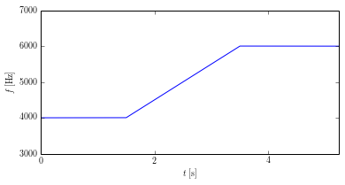

```python
S.plot_phase_fit()
```

## Experimental data

### Read in the signal

... which is stored, compactly, in a `HDF5` type file.

```python
import h5py
with h5py.File('JAM_9p90__copy.h5', 'r') as h5f:
    s = h5f['s'][:]
```

### Create the Signal objec, demodulate it, and fit the phase vs time data

... to recover the oscillation frequency. We have a few choices to make:

- We choose window rise/fall time of 10 ms.
- We choose a filter bandwidth of 1 kHz -- large enough to capture a ms transient but small enough to give us some signal averaging.
- Choose the "chunk" time to be 0.5 ms; the associated Nyquist frequency is 2 kHz -- larger than the filter bandwidth.

```python
S = Signal(s,"x","nm",1/1.15E6)
S.binarate("middle")
S.window(tw=10.0E-3)
S.fft()
S.filter(bw=1.0E3)
S.ifft()
S.trim()
S.fit(dt_chunk_target=0.50E-3)
print(S)
```

```
Signal
======
signal name: x
signal unit: nm
signal lenth = 524288
time step = 0.870 us
rms = 0.1486
max = 0.1885
min = -0.2339

Signal Report
=============
* Add a signal x[nm] of length 762375, time step 0.870 us, and duration 0.663 s

* Truncate the signal to be 524288 points long, a power of two. This was done by chopping points off the beginning and end of the signal array, that is, by using points 119043 up to 643331.

* Window the signal with a rising/falling blackman filter having a rise/fall time of 10000.000 us (11500 points).

* Fourier transform the windowed signal. It took 153.0 ms to compute the FFT.

* Reject negative frequencies, apply a bandpass filter of bandwidth 1000.0 Hz & order 50, and set the delay time to 1250.0 us.

* Apply an inverse Fourier transform.

* Remove the leading and trailing ripple (1437 points) from the complex signal. Compute the signal phase and amplitude.

* Curve fit the phase data. The target chunk duration is 500.000 us; the actual chunk duration is 500.000 us (575 points). 906 chunks will be curve fit; 453.000 ms of data. It took 30.4 ms to perform the curve fit and obtain the frequency.
```

### Plot the frequency *vs* time

```
number of elements = 906
number of nan = 0
```

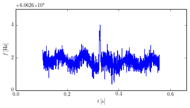

```python
print "number of elements = {}".format(S.signal['fit_freq'].size)
print "number of nan = {}".format(np.count_nonzero(np.isnan(S.signal['fit_freq'])))

S.plot_phase_fit()
```

### Replot the frequency shift

There is an interesting blip in the middle that we want to take a closer look at. To do this, compute a frequency shift; zoom in to the middle section of the data; and plot *vs* time shift in ms.

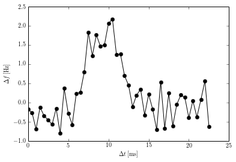

```python
import matplotlib.pyplot as plt
import copy

# make a copy of the fitten data

fit_freq_temp = copy.deepcopy(S.signal['fit_freq'])
fit_time_temp = copy.deepcopy(S.signal['fit_time'])

# caculate a frequency shift by subtrating off
#  the average over the first third of the data

fit_freq_size = fit_freq_temp.size
fit_freq_size_avg = fit_freq_temp[0:fit_freq_size/3].mean()
fit_freq_temp = fit_freq_temp - fit_freq_size_avg

# define a zoom window -- define as a perecentage
#  the the window still works if we change the chunk time
#  for curve fitting

start = 0.47*fit_freq_size
stop = 0.52*fit_freq_size

# plot the frequency shift [Hz] versus time [ms]
#  reset the time at the start of the plot to zero

x = 1E3*(fit_time_temp[start:stop] - fit_time_temp[start])
y = fit_freq_temp[start:stop]

plt.rcParams['text.usetex'] = True

plt.plot(x,y,'ko-')
plt.ylabel(r"$\Delta f \: \mathrm{[Hz]}$")
plt.xlabel(r"$\Delta t \: \mathrm{[ms]}$")
plt.show()
```